# Demonstration 8: Categorical Indicators

SEM in R using lavaan

Kyle M. Lang

Updated: 2026-03-25

In this demonstration, we’ll explore methods of doing CFA/SEM with categorical data using **lavaan**.

# 1 Background

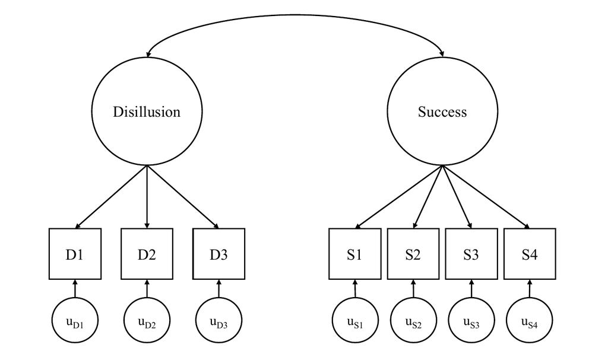

Figure 1.1: Continous Variable CFA

For the most part, the models we’ve been working with in this course have a form similar to the CFA shown in Figure 1.1. In such models, the observed indicators $\{D1, D2, \ldots, S4\}$ act as dependent variables in a multivariate linear model that is estimated using maximum likelihood (ML).

Since ML works by numerically optimizing some likelihood function, we must assume some distribution for the observed data to define this likelihood function. In **lavaan** (as in most applications), this distribution is the multivariate normal. If this assumption does not hold (i.e., the observed data are not multivariate normally distributed), we can encounter different problems.

1. Biased parameter estimates
2. Incorrect standard errors (usually too small)
3. Incorrect fit statistics (usually too optimistic)

The multivariate normality assumption can be violated in many ways (e.g., highly skewed or kurtotic indicators), but we are here concerned with violations caused by categorical indicators (i.e., binary/dichotomous or ordinal variables). At the time of writing, **lavaan** cannot accommodate nominal indicators with more than two levels (e.g., grouping factors with 3+ groups), so we will restrict our discussion to binary and ordinal data.

## 1.1 Polychoric Correlations

To understand the problems that arise when naively modeling categorical indicators as though they were continuous, it is helpful to step back to the basic problem of estimating bivariate correlations.

The following code generates a dataset, $\mathbf{X}$, containing 100000 observations from a bivariate normal distribution wherein the two variables, $x1$ and $x2$, are correlated at $\rho = 0.5$.

```r
library(mvtnorm)
library(polycor)

## Generate some multivariate normal data:
X <- rmvnorm(100000, c(0, 0), matrix(c(1.0, 0.5, 0.5, 1.0), 2, 2)) |>
  data.frame() |>
  rename_with(tolower)

colMeans(X)
```

```
          x1           x2
-0.002316504 -0.003413107
```

```r
cor(X)
```

```
          x1        x2
x1 1.0000000 0.4972098
x2 0.4972098 1.0000000
```

Now, we’ll create ordinal variables, $z1$ and $z2$, by coarsening $x1$ and $x2$ to simulate a situation wherein we are only able to measure a discrete approximation of the true underlying continuous variables.

```r
## Coarsen the data:
Z <- X |> mutate(z1 = cut(x1, c(-Inf, -0.7, 0.5, Inf), labels = FALSE),
                 z2 = cut(x2, c(-Inf, -0.5, 1.0, Inf), labels = FALSE),
                 .keep = "none")
```

Finally, we’ll calculate three different flavors of bivariate correlation to evaluate the effect of coarsening and potential remedies.

1. The Pearson product moment correlation between $x1$ and $x2$.
   - In reality, we would not be able to calculate this value, but we’d like to have some means of estimating this association. We care about the relation between $x1$ and $x2$ in the population (where they are continuous variables), not the association between the coarsened versions, $z1$ and $z2$, that we have in our data.
2. The Pearson product moment correlation between $z1$ and $z2$.
   - This is the correlation we would get if we naively calculated a standard correlation from our data.
3. The polychoric correlation between $z1$ and $z2$.
   - This value is meant to estimate the true association between the underlying continuous variables using only their coarsened representations.

```r
## Compare different correlations:
X %$% cor(x1, x2)
```

```
[1] 0.4972098
```

```r
Z %$% cor(z1, z2)
```

```
[1] 0.4027203
```

```r
Z %$% polychor(z1, z2)
```

```
[1] 0.4975206
```

When we naively estimate the correlation from the coarsened variables, we see a substantial attenuation, which we’d expect due to the restriction of range induced by the coarsening. The polychoric correlation, on the other hand, accurately estimates the correlation between the underlying latent response factors.

### 1.1.1 Relevance to CFA/SEM

So, why should we care about this polychoric correlation business? Well, it turns out that the methods we’ll use to model ordinal indicators apply a similar logic. In standard ML, we estimate the model parameters by minimizing the following loss function:

$$F_{\mathit{ML}} = \ln | \Sigma | + tr(\mathbf{S}\Sigma^{-1}) - \ln | \mathbf{S} | - p$$

Where $\mathbf{S}$ is the observed covariance matrix of the indicators, $\Sigma$ is the corresponding model-implied covariance matrix, and $p$ is the number of observed variables in the model.

If we apply this approach to ordinal data and, hence, naively compute $\mathbf{S}$ from ordinal indicators, we get the same attenuated measures of association seen in the toy example above. This attenuation propagates throughout the model and biases the estimated CFA/SEM parameters.

## 1.2 Modeling Categorical Indicators

In essence, the estimation methods we’ll employ when analyzing categorical indicators replace $\mathbf{S}$ with a polychoric correlation matrix. Rather than simply estimating a standalone polychoric correlation matrix and using this matrix as input to the model, however, **lavaan** implements a version of the *categorical variable methodology* (CVM) proposed by Muthén (1984).

We could set up a CVM analysis in many ways, but the recommended **lavaan** flavor entails four modifications to the standard ML approach:

1. Extending the measurement model by adding latent response variables
2. Estimate the model with diagonally weighted least squares
3. Estimate the standard errors with robust sandwich estimators
4. Evaluate model fit using mean and variance adjusted fit indices

### 1.2.1 Latent Response Variables

The first step in CVM is to extend the basic definition of the measurement model by including so-called *latent response variables* (LRVs) that represent the continuous variables assumed to underlie the observed ordinal indicators. In terms of the toy example above, our data contain $z1$ and $z2$, but the LRVs represent $x1$ and $x2$.

The modified version of the CFA from above would look something like the following.

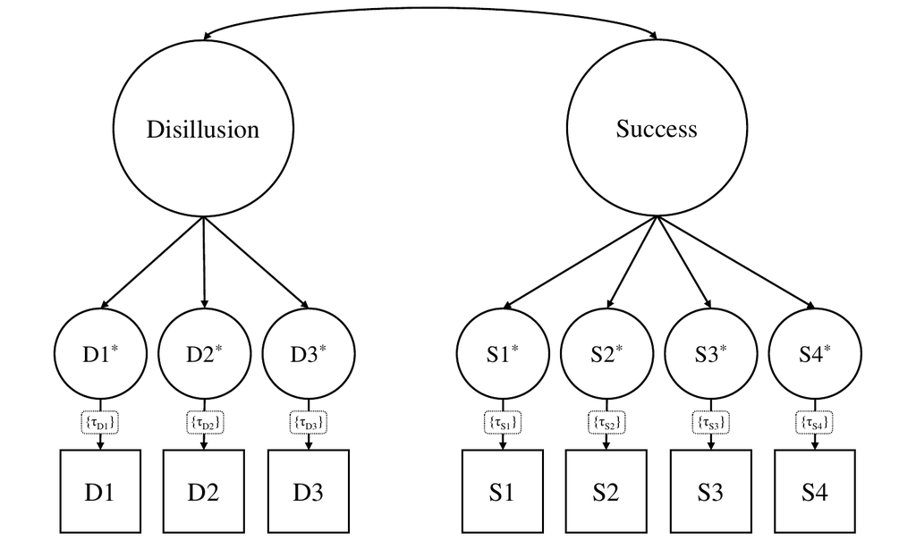

Figure 1.2: CFA with Latent Response Variables

### 1.2.2 Item Thresholds

To define the LRVs, $\{D1^*, D2^*, \ldots, S4^*\}$, we must introduce a new layer of measurement parameters: the item thresholds, $\{\tau_{D1}\}, \{\tau_{D1}\}, \ldots, \{\tau_{S4}\}$.

To estimate the LRV underlying an ordinal variable with $G$ levels we need $G - 1$ thresholds. Each threshold represents the “tipping point” at which the level of the underlying LRV crosses into a new regime that translates to the next level of the observed indicator.

Using the toy data from the above polychoric correlation example, we can visualize the putative data generating process through which the underlying latent version of a variable ($x2$, in this case) is assumed to give rise to the observed, ordinal $z2$.

**1. Visualize the distribution of the latent response.**

We assume that the putative concept tapped by our item, $x2$, is continuous in the wild.

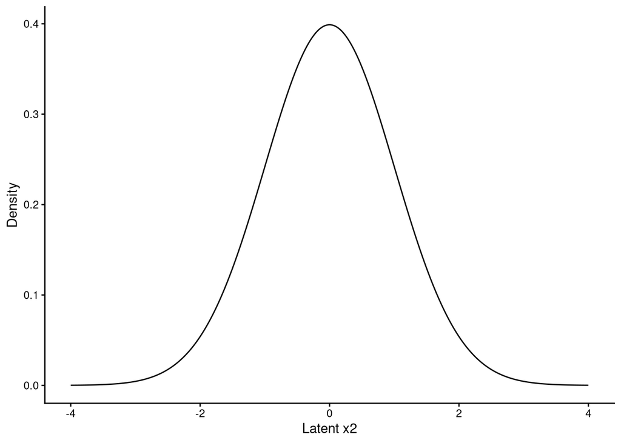

**2. Overlay the thresholds.**

For some reason, however, we are only able to assess the concept in a discrete way (e.g., by collecting data using rating scales). We assume there is some implicit coarsening process that translates the true level of the continuous LRV to the discrete levels we measure.

The thresholds divide the underlying continuous distribution into ranges that will end up translating to different levels of the discrete response we are able to measure.

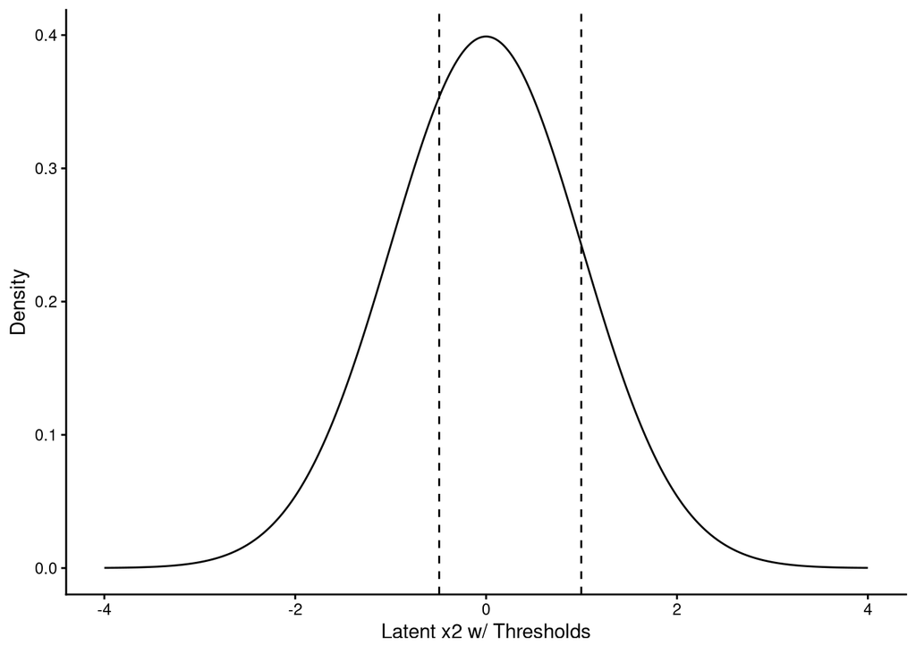

**3. Color-code the ranges defined by the thresholds.**

In this case, we’ve measured a three-level factor. So, two thresholds partition the distribution of $x2$ into the following three ranges.

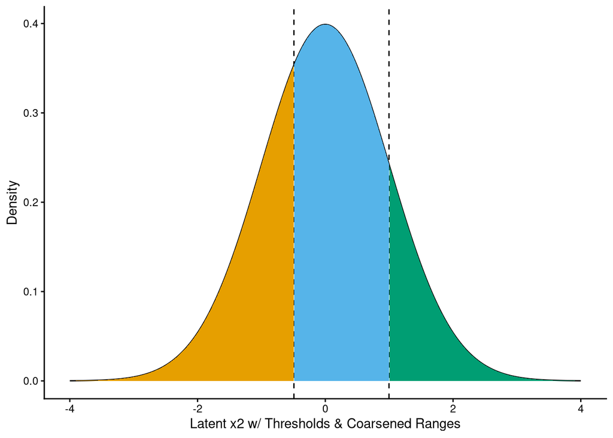

**4. Bin the observations according to their thresholded range to coarsen the variable.**

This barplot represents the distribution of the observed data that we have actually collected.

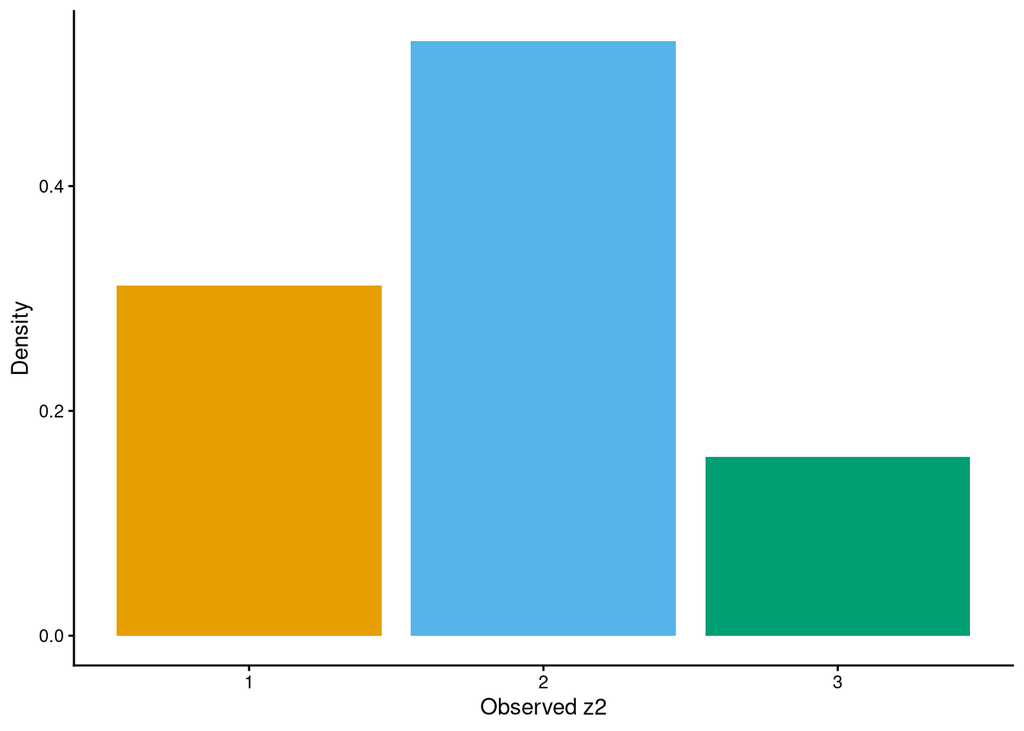

When we estimate a measurement model including LRVs, we essentially reverse the process illustrated above.

1. We first estimate the thresholds from the observed cross-tabulation of our discrete indicators.
2. We use these thresholds to define the LRVs under the assumption that these LRVs follow a multivariate normal distribution.
   - More general definitions are possible, but **lavaan** assumes a multivariate normal distribution for the LRVs.
3. We can then estimate a standard CFA wherein the LRVs act as the indicators or the common latent factors.

The covariance matrix of the latent response variables is equivalent to the polychoric correlation matrix of the ordinal indicators. So, applying this procedure corrects for the attenuation caused by naively analyzing ordinal items with continuous variable methodology.

### 1.2.3 Estimation

In **lavaan**, we cannot use ML to estimate models that include latent response factors such as the CFA represented in Figure 1.2. We need to use one of two possible alternatives:

1. *Weighted Least Squares* (WLS)
   - `estimator = "wls"`
2. *Diagonally Weighted Least Squares* (DWLS)
   - `estimator = "dwls"`

In practice, however, we will almost always want to use DWLS.

Both WLS and DWLS use loss functions of the following form.

$$F_{\mathit{WLS}} = (\mathbf{r} - \rho)^T \mathbf{W}^{-1} (\mathbf{r} - \rho)$$

Where $\mathbf{r}$ is a vector containing the unique thresholds and polychoric correlations, $\rho$ is the analogous vector of model-implied statistics, and $\mathbf{W}$ is (some part of) the asymptotic covariance matrix of the elements in $\mathbf{r}$ (which acts as a weighting matrix).

We generally prefer DWLS because of how the two estimators define $\mathbf{W}$. WLS uses the entire asymptotic covariance matrix for $\mathbf{W}$, whereas DWLS uses only the diagonal elements. Naturally, the size of this matrix grows rapidly as more variables are added to the model. WLS requires very large samples to invert $\mathbf{W}$ without computational problems. Since DWLS needs only to invert the diagonal elements of $\mathbf{W}$, it is much more stable and does not require such large samples.

#### 1.2.3.1 Standard Errors and Fit Statistics

Although simply estimating the LRV-formulated model with DWLS will suffice to provide unbiased parameter estimates. The resulting standard errors and fit statistics will typically be adversely affected (i.e., SEs are usually too small and fit statistics are usually too optimistic). These effects are more pronounced when the indicators are substantially skewed or kurtotic.

Fortunately, these problems are easily addressed by using a robust sandwich-style estimator for the standard errors (e.g., by specifying `se = "robust"`) and a scaled version of the fit statistics (e.g., by specifying `test = "scaled.shifted"`).

For convenience, we can request the recommended combination by specifying the `estimator = wlsmv` option (mirroring MPlus nomenclature). The `estimator = wlsmv` option implies the following parameterization.

- DWLS estimation
- Robust standard errors
- Mean and variance adjusted fit statistics

## 1.3 Additional Resources

Paul Johnson[^1] has a nice set of lecture slides covering the basic ideas we’re considering here.

- [CRMDA Workshop: Ordinal Variable SEM](https://pj.freefaculty.org/guides/crmda_workshops/sem/sem-3/sem-3-3-sem_ordinal/sem-3-3-sem_ordinal.pdf)

Although the following chapter is locked behind a paywall, it nevertheless gives the best overall summary of these ideas that I have yet found. If you can track down a copy, I’d strongly recommend giving it a read.

- Finney, S. J., & DiStefano, C. (2006). Nonnormal and categorical data in structural equation modeling. In G. R. Hancock & R. O. Mueller (Eds.), *Structural equation modeling: A second course* (pp. 269 – 314). Information Age Publishing.

The **lavaan** tutorial pages provide a brief overview of the options available for modeling categorical data in **lavaan**.

- [**lavaan** Tutorial: Categorical Data](https://lavaan.ugent.be/tutorial/cat.html)

OK, that’s enough background. Let’s take a look at some actual analyses.

# 2 Data

We will revisit the synthetic [*Outlook on Life Survey*](https://doi.org/10.3886/ICPSR35348.v1) data from Lab 5. Recall that the original data were collected in the United States in 2012 to measure, among other things, attitudes about racial issues, opinions of the Federal government, and beliefs about the future.

We will again work with a synthesized subset of the original data. You can access these synthetic data as [*outlook.rds*](https://github.com/kylelang/lavaan-e-learning/raw/main/data/outlook.rds). This dataset comprises 2288 observations of the following 13 variables.

- `d1:d3`: Three observed indicators of a construct measuring disillusionment with the US Federal government.
  - Higher scores indicate more disillusionment $\\[3pt]$
- `s1:s4`: Four observed indicators of a construct measuring the perceived achievability of material success.
  - Higher scores indicate greater perceived achievability $\\[3pt]$
- `progress`: A single item assessing perceived progress toward achieving the “American Dream”
  - Higher scores indicate greater perceived progress $\\[3pt]$
- `merit`: A single item assessing endorsement of the meritocratic ideal that hard work leads to success.
  - Higher scores indicate stronger endorsement of the meritocratic ideal $\\[3pt]$
- `lib2Con`: A single item assessing liberal-to-conservative orientation
  - Lower scores are more liberal, higher scores are more conservative $\\[3pt]$
- `party`: A four-level factor indicating self-reported political party affiliation $\\[3pt]$
- `disillusion`: A scale score representing disillusionment with the US Federal government
  - Created as the mean of `d1:d3` $\\[3pt]$
- `success`: A scale score representing the perceived achievability of material success
  - Created as the mean of `s1:s4`

First, we’ll read in the *outlook.rds* dataset, and save the resulting data frame as `outlook`.

```r
dataDir <- "data"
outlook <- readRDS(here::here(dataDir, "outlook.rds"))
```

For the following, we don’t need/want the scale scores for *disillusionment* or *success* or the observations for which `party = "other"`. The following code will exclude these parts of the dataset.

```r
library(dplyr)
library(magrittr)

outlook %<>% select(-disillusion, -success) %>%
   filter(party != "other") %>%
   mutate(party = droplevels(party))
```

Now, we’ll explore our data a bit and summarize the distributions of the *disillusionment* and *success* items.

```r
tmp <- outlook |> select(d1:s4)

head(tmp)
```

|  | d1 | d2 | d3 | s1 | s2 | s3 | s4 |
| --- | --- | --- | --- | --- | --- | --- | --- |
| 1 | 4 | 4 | 4 | 3 | 2 | 3 | 3 |
| 2 | 4 | 2 | 4 | 3 | 2 | 2 | 3 |
| 3 | 4 | 4 | 4 | 4 | 2 | 4 | 3 |
| 4 | 5 | 4 | 5 | 2 | 1 | 1 | 1 |
| 5 | 5 | 3 | 4 | 2 | 1 | 2 | 2 |
| 6 | 4 | 5 | 4 | 2 | 2 | 1 | 3 |

```r
summary(tmp)
```

```
       d1              d2              d3              s1
 Min.   :1.000   Min.   :1.000   Min.   :1.000   Min.   :1.000
 1st Qu.:3.000   1st Qu.:2.000   1st Qu.:3.000   1st Qu.:2.000
 Median :4.000   Median :3.000   Median :4.000   Median :2.000
 Mean   :3.626   Mean   :3.205   Mean   :3.617   Mean   :2.289
 3rd Qu.:4.000   3rd Qu.:4.000   3rd Qu.:4.000   3rd Qu.:3.000
 Max.   :5.000   Max.   :5.000   Max.   :5.000   Max.   :4.000
       s2              s3              s4
 Min.   :1.000   Min.   :1.000   Min.   :1.000
 1st Qu.:1.000   1st Qu.:1.000   1st Qu.:2.000
 Median :2.000   Median :2.000   Median :2.000
 Mean   :1.924   Mean   :2.009   Mean   :2.469
 3rd Qu.:2.000   3rd Qu.:3.000   3rd Qu.:3.000
 Max.   :4.000   Max.   :4.000   Max.   :4.000
```

```r
lapply(tmp, unique)
```

```
$d1
[1] 4 5 3 2 1

$d2
[1] 4 2 3 5 1

$d3
[1] 4 5 3 2 1

$s1
[1] 3 4 2 1

$s2
[1] 2 1 3 4

$s3
[1] 3 2 4 1

$s4
[1] 3 1 2 4
```

Clearly, these variables are not continuous and have some sort of discrete scale. Although we cannot tell simply from the numeric summaries above, these items represent questionnaire responses on 4- and 5-point rating scales.

It would probably not be a very good idea to naively analyze these items as continuous indicators. Let’s see how we get on with a more principled treatment.

# 3 Categorical Variable CFA

Let’s assume we want to fit the CFA model depicted in Figure 1.2. The following **lavaan** model syntax will suffice to define our model.

```r
cfaMod <- '
disillusion =~ d1 + d2 + d3
success =~ s1 + s2 + s3 + s4
'
```

## 3.1 Naive Fit

First, as a point of comparison, we’ll use ML to naively fit the basic CFA shown in Figure 1.1.

```r
library(lavaan)

## Naive ML fit:
fit0 <- cfa(cfaMod, data = outlook, std.lv = TRUE)

summary(fit0)
```

```
lavaan 0.6-21 ended normally after 17 iterations

  Estimator                                         ML
  Optimization method                           NLMINB
  Number of model parameters                        15

  Number of observations                          2172

Model Test User Model:

  Test statistic                                30.223
  Degrees of freedom                                13
  P-value (Chi-square)                           0.004

Parameter Estimates:

  Standard errors                             Standard
  Information                                 Expected
  Information saturated (h1) model          Structured

Latent Variables:
                   Estimate  Std.Err  z-value  P(>|z|)
  disillusion =~
    d1                0.719    0.028   25.542    0.000
    d2                0.696    0.030   23.045    0.000
    d3                0.474    0.021   23.061    0.000
  success =~
    s1                0.636    0.019   34.322    0.000
    s2                0.608    0.017   35.586    0.000
    s3                0.613    0.018   34.541    0.000
    s4                0.547    0.019   28.392    0.000

Covariances:
                   Estimate  Std.Err  z-value  P(>|z|)
  disillusion ~~
    success          -0.264    0.028   -9.377    0.000

Variances:
                   Estimate  Std.Err  z-value  P(>|z|)
   .d1                0.586    0.034   17.264    0.000
   .d2                0.892    0.039   23.118    0.000
   .d3                0.413    0.018   23.087    0.000
   .s1                0.379    0.016   23.749    0.000
   .s2                0.304    0.014   22.470    0.000
   .s3                0.344    0.015   23.539    0.000
   .s4                0.493    0.018   27.834    0.000
    disillusion       1.000
    success           1.000
```

## 3.2 Basic DWLS Fit

Now, we’ll fit the appropriate LRV-formulated model using DWLS, but we won’t yet request robust SEs or fit statistics.

```r
## Basic DWLS fit:
fit1.1 <- cfa(cfaMod,
              data = outlook,
              std.lv = TRUE,
              ordered = TRUE,     # Tell lavaan that our data are ordinal
              estimator = "DWLS", # Use DWLS to estimate the model
              se = "standard")    # Don't correct the standard errors

summary(fit1.1)
```

```
lavaan 0.6-21 ended normally after 14 iterations

  Estimator                                       DWLS
  Optimization method                           NLMINB
  Number of model parameters                        32

  Number of observations                          2172

Model Test User Model:

  Test statistic                                23.749
  Degrees of freedom                                13
  P-value (Unknown)                                 NA

Parameter Estimates:

  Parameterization                               Delta
  Standard errors                             Standard
  Information                                 Expected
  Information saturated (h1) model        Unstructured

Latent Variables:
                   Estimate  Std.Err  z-value  P(>|z|)
  disillusion =~
    d1                0.716    0.023   31.135    0.000
    d2                0.631    0.021   30.527    0.000
    d3                0.648    0.021   30.515    0.000
  success =~
    s1                0.761    0.014   55.755    0.000
    s2                0.800    0.014   56.540    0.000
    s3                0.771    0.014   55.557    0.000
    s4                0.667    0.014   49.067    0.000

Covariances:
                   Estimate  Std.Err  z-value  P(>|z|)
  disillusion ~~
    success          -0.275    0.014  -19.920    0.000

Thresholds:
                   Estimate  Std.Err  z-value  P(>|z|)
```

[output cut: 21 more lines]

```
    s4|t1            -1.062    0.033  -31.982    0.000
    s4|t2             0.035    0.027    1.287    0.198
    s4|t3             1.140    0.034   33.219    0.000

Variances:
                   Estimate  Std.Err  z-value  P(>|z|)
   .d1                0.487
   .d2                0.601
   .d3                0.580
   .s1                0.421
   .s2                0.360
   .s3                0.406
   .s4                0.555
    disillusion       1.000
    success           1.000
```

Notice that the model now contains a set of estimated thresholds to define the latent response factors.

We can actually calculate these thresholds directly from the raw data in a few simple steps.

1. Calculate the cumulative frequencies of each response level.
2. Convert these cumulative frequencies to proportions.
3. For each proportion, calculate the quantile on the standard normal distribution that “cuts off” that proportion of the lower tail.
   - These quantiles are the estimated thresholds.

```r
## Define a function to calculate thresholds from the raw data:
calcThresholds <- function(x) {
   cummulants <- table(x) |> cumsum()
   probs <- head(cummulants, -1) / tail(cummulants, 1)
   qnorm(probs)
}

## Calculate the thresholds from the data:
manual <- outlook |> select(d1:s4) |> lapply(calcThresholds) |> unlist()

## Extract the estimated thresholds from the model estimated by lavaan:
lavaan <- lavInspect(fit1.1, "est")$tau
```

When we compare the manual approach to **lavaan**’s estimates, we see the expected equivalence.

|  | manual | lavaan |
| --- | --- | --- |
| d1\|t1 | -1.7886896 | -1.7886896 |
| d1\|t2 | -1.1077824 | -1.1077824 |
| d1\|t3 | -0.1763273 | -0.1763273 |
| d1\|t4 | 0.7488303 | 0.7488303 |
| d2\|t1 | -1.2847060 | -1.2847060 |
| d2\|t2 | -0.6023197 | -0.6023197 |
| d2\|t3 | 0.1412643 | 0.1412643 |
| d2\|t4 | 1.1056533 | 1.1056533 |
| d3\|t1 | -2.3571419 | -2.3571419 |
| d3\|t2 | -1.3920600 | -1.3920600 |
| d3\|t3 | -0.2746182 | -0.2746182 |
| d3\|t4 | 1.2794556 | 1.2794556 |
| s1\|t1 | -0.8672236 | -0.8672236 |
| s1\|t2 | 0.2890281 | 0.2890281 |
| s1\|t3 | 1.3060706 | 1.3060706 |
| s2\|t1 | -0.4319939 | -0.4319939 |
| s2\|t2 | 0.7970631 | 0.7970631 |
| s2\|t3 | 1.6990031 | 1.6990031 |
| s3\|t1 | -0.5251952 | -0.5251952 |
| s3\|t2 | 0.6643823 | 0.6643823 |
| s3\|t3 | 1.5918516 | 1.5918516 |
| s4\|t1 | -1.0620486 | -1.0620486 |
| s4\|t2 | 0.0346289 | 0.0346289 |
| s4\|t3 | 1.1403425 | 1.1403425 |

It’s also interesting to note that the latent correlation is stronger in the DWLS model. The attenuation in the ML model is caused by the same type of restriction-of-range attenuation discussed in the toy polychoric correlation example above.

|  | ML | DWLS |
| --- | --- | --- |
| Latent Covariance | -0.264 | -0.275 |

## 3.3 Robust DWLS Fit

Finally, we’ll do things the right way by estimating the model with DWLS and using robust SEs and scaled fit statistics.

```r
## Robust DWLS fit:
fit1.2 <- cfa(cfaMod,
              data = outlook,
              std.lv = TRUE,
              ordered = TRUE,
              estimator = "WLSMV")

summary(fit1.2)
```

```
lavaan 0.6-21 ended normally after 14 iterations

  Estimator                                       DWLS
  Optimization method                           NLMINB
  Number of model parameters                        32

  Number of observations                          2172

Model Test User Model:
                                              Standard      Scaled
  Test Statistic                                23.749      37.139
  Degrees of freedom                                13          13
  P-value (Unknown)                                 NA       0.000
  Scaling correction factor                                  0.674
  Shift parameter                                            1.917
    simple second-order correction

Parameter Estimates:

  Parameterization                               Delta
  Standard errors                           Robust.sem
  Information                                 Expected
  Information saturated (h1) model        Unstructured

Latent Variables:
                   Estimate  Std.Err  z-value  P(>|z|)
  disillusion =~
    d1                0.716    0.022   33.042    0.000
    d2                0.631    0.021   29.729    0.000
    d3                0.648    0.021   30.323    0.000
  success =~
    s1                0.761    0.013   57.152    0.000
    s2                0.800    0.013   63.828    0.000
    s3                0.771    0.013   57.802    0.000
    s4                0.667    0.015   43.632    0.000

Covariances:
                   Estimate  Std.Err  z-value  P(>|z|)
  disillusion ~~
    success          -0.275    0.028   -9.657    0.000
```

[output cut: 24 more lines]

```
    s4|t1            -1.062    0.033  -31.982    0.000
    s4|t2             0.035    0.027    1.287    0.198
    s4|t3             1.140    0.034   33.219    0.000

Variances:
                   Estimate  Std.Err  z-value  P(>|z|)
   .d1                0.487
   .d2                0.601
   .d3                0.580
   .s1                0.421
   .s2                0.360
   .s3                0.406
   .s4                0.555
    disillusion       1.000
    success           1.000
```

Notice that the parameter estimates are identical in the normal and robust versions of the DWLS fit since we’re using the same estimator to fit both models.

```r
all.equal(coef(fit1.1), coef(fit1.2))
```

```
[1] TRUE
```

We start to see differences when we compare the standard errors.

```r
## Basic DWLS estimates:
partSummary(fit1.1, c(7:8))
```

```
Latent Variables:
                   Estimate  Std.Err  z-value  P(>|z|)
  disillusion =~
    d1                0.716    0.023   31.135    0.000
    d2                0.631    0.021   30.527    0.000
    d3                0.648    0.021   30.515    0.000
  success =~
    s1                0.761    0.014   55.755    0.000
    s2                0.800    0.014   56.540    0.000
    s3                0.771    0.014   55.557    0.000
    s4                0.667    0.014   49.067    0.000

Covariances:
                   Estimate  Std.Err  z-value  P(>|z|)
  disillusion ~~
    success          -0.275    0.014  -19.920    0.000
```

```r
## Robust DWLS estimates:
partSummary(fit1.2, c(7:8))
```

```
Latent Variables:
                   Estimate  Std.Err  z-value  P(>|z|)
  disillusion =~
    d1                0.716    0.022   33.042    0.000
    d2                0.631    0.021   29.729    0.000
    d3                0.648    0.021   30.323    0.000
  success =~
    s1                0.761    0.013   57.152    0.000
    s2                0.800    0.013   63.828    0.000
    s3                0.771    0.013   57.802    0.000
    s4                0.667    0.015   43.632    0.000

Covariances:
                   Estimate  Std.Err  z-value  P(>|z|)
  disillusion ~~
    success          -0.275    0.028   -9.657    0.000
```

### 3.3.1 Fit Statistics

```r
## Fit statistics for the basic DWLS fit:
fitMeasures(fit1.1)
```

```
                 npar                  fmin                 chisq
               32.000                 0.005                23.749
                   df                pvalue        baseline.chisq
               13.000                    NA              9439.299
          baseline.df       baseline.pvalue                   cfi
               21.000                    NA                 0.999
                  tli                  nnfi                   rfi
                0.998                 0.998                 0.996
                  nfi                  pnfi                   ifi
                0.997                 0.617                 0.999
                  rni                 rmsea        rmsea.ci.lower
                0.999                 0.020                 0.005
       rmsea.ci.upper        rmsea.ci.level          rmsea.pvalue
                0.032                 0.900                 1.000
       rmsea.close.h0 rmsea.notclose.pvalue     rmsea.notclose.h0
                0.050                 0.000                 0.080
                  rmr            rmr_nomean                  srmr
                0.015                 0.021                 0.021
         srmr_bentler   srmr_bentler_nomean                  crmr
                0.015                 0.021                 0.017
          crmr_nomean            srmr_mplus     srmr_mplus_nomean
                0.024                    NA                    NA
                cn_05                 cn_01                   gfi
             2045.171              2532.055                 0.999
                 agfi                  pgfi                   mfi
                0.997                 0.289                 0.998
                 wrmr
                0.726
```

When estimating the model with `estimator = "WLSMV"`, we implicitly set `test = "scaled.shifted"`, so `fitMeasures()` now returns three variants of our main fit measures:

- Raw, uncorrected statistics
- Scaled statistics
- Robust statistics

```r
## Fit statistics for the robust DWLS fit:
fitMeasures(fit1.2)
```

```
                         npar                          fmin
                       32.000                         0.005
                        chisq                            df
                       23.749                        13.000
                       pvalue                  chisq.scaled
                           NA                        37.139
                    df.scaled                 pvalue.scaled
                       13.000                         0.000
         chisq.scaling.factor                baseline.chisq
                        0.674                      9439.299
                  baseline.df               baseline.pvalue
                       21.000                            NA
        baseline.chisq.scaled            baseline.df.scaled
                     6324.973                        21.000
       baseline.pvalue.scaled baseline.chisq.scaling.factor
                        0.000                         1.494
                          cfi                           tli
                        0.999                         0.998
                   cfi.scaled                    tli.scaled
                        0.996                         0.994
                   cfi.robust                    tli.robust
                        0.995                         0.991
                         nnfi                           rfi
                        0.998                         0.996
                          nfi                          pnfi
                        0.997                         0.617
                          ifi                           rni
                        0.999                         0.999
                  nnfi.scaled                    rfi.scaled
                        0.994                         0.991
                   nfi.scaled                   pnfi.scaled
                        0.994                         0.615
                   ifi.scaled                    rni.scaled
                        0.996                         0.996
                  nnfi.robust                    rni.robust
                        0.991                         0.995
                        rmsea                rmsea.ci.lower
                        0.020                         0.005
               rmsea.ci.upper                rmsea.ci.level
                        0.032                         0.900
```

[output cut: 17 more lines]

```
                        0.021                         0.015
          srmr_bentler_nomean                          crmr
                        0.021                         0.017
                  crmr_nomean                    srmr_mplus
                        0.024                            NA
            srmr_mplus_nomean                         cn_05
                           NA                      2045.171
                        cn_01                           gfi
                     2532.055                         0.999
                         agfi                          pgfi
                        0.997                         0.289
                          mfi                          wrmr
                        0.998                         0.726
attr(,"scaled.test")
[1] "scaled.shifted"
```

The scaled/robust fit statistics/indices typically suggest worse fit than the raw versions. It should come as no surprise that we need to use the corrected fit statistics to evaluate our model, but which variant? That part’s not quite as obvious.

The short answer: *Report the scaled fit statistics when modeling categorical indicators with WLSMV estimation.*

Table 3.1: Different flavors of fit indices

|  | $\chi^2$ | DF | p-value | CFI | TLI | RMSEA | RMSEA 90% CI |
| --- | --- | --- | --- | --- | --- | --- | --- |
| Raw | 23.749 | 13 | NA | 0.999 | 0.998 | 0.02 | [0.005; 0.032] |
| Scaled | 37.139 | 13 | < 0.001 | 0.996 | 0.994 | 0.029 | [0.018; 0.041] |
| Robust | - | - | - | 0.995 | 0.991 | 0.03 | [0.017; 0.043] |

#### What are the differences?

The long answer requires us to consider the differences between the different flavors of fit statistic.

The raw, uncorrected fit statistics are computed using the same procedure that we’ve been using for ML-based analyses of continuous data. These statistics are all based on the ordinary ML $\chi^2$ statistic, so they *do not* accurately quantify model fit for LRV-formulated models estimated with DWLS. Typically, the raw fit statistics suggest overly optimistic fit.

The scaled fit statistics are based on the scaled-and-shifted $\chi^2$ (AKA, mean and variance adjusted $\chi^2$) developed by Satorra & Bentler (1994) and later refined by Asparouhov & Muthén (2010). The scaled CFI, TLI, and RMSEA values are computed by plugging the scaled-and-shifted $\chi^1$ into the standard formulas.

The `fitMeasures()` function doesn’t return a robust $\chi^2$ value because the scaled-and-shifted $\chi^2$ is already sufficiently robust. Only the CFI, TLI, and RMSEA have different scaled and robust versions. The robust versions of these statistics are based on the scaled-and-shifted $\chi^2$, but they also include the additional correction factor proposed by Savalei (2018).

#### Scaled or Robust?

If you’re anything like me, it won’t be obvious at this point whether you should use the scaled or robust versions of the CFI, TLI, and RMSEA. Since the robust versions have a more elaborate correction, you may be inclined to report those, but doing so would be a mistake. The robust fit statistics are indeed the most refined and accurate variants, *but not for the kinds of models we’re estimating here*. The theoretical basis for the additional correction factor assumes continuous, non-normal data (e.g., skewed data like reaction times) and robust ML estimation (e.g., `estimator = "MLR"`). The key assumptions needed to justify this additional correction don’t hold for categorical data and DWLS estimation. Hence, the robust fit statistics are not appropriate for categorical indicator models, and we’re better off using the scaled versions of CFI, TLI, and RMSEA.

## 3.4 Alternative `cfa()` Specifications

When estimating the last model, we actually used a bit of a shortcut. By setting `ordered = TRUE`, we tell the `cfa()` function that all of our observed data are ordinal (the same will hold for `lavaan()` or any of its other wrappers). This approach won’t work when our model also contains continuous variables. Fortunately, there are two alternative means of flagging ordinal variables.

The `ordered` argument accepts a character vector containing the names of the ordinal variables.

```r
## Explicitly name the ordinal variables:
fit1.2.1 <- cfa(cfaMod,
              data = outlook,
              std.lv = TRUE,
              ordered = c(paste0("d", 1:3), paste0("s", 1:4)),
              estimator = "WLSMV")
```

We can also type cast the ordinal variables as ordered factors and provide the typed data to the `data` argument. When taking this approach, the `ordered` argument is not necessary.

```r
## Cast the ordinal variables as ordered factors in the data frame:
fit1.2.2 <- outlook |> mutate(across(d1:s4, as.ordered)) |>
   cfa(cfaMod,
       data = _,
       std.lv = TRUE,
       estimator = "WLSMV")
```

All three approaches have the same effect.

```r
all.equal(coef(fit1.2), coef(fit1.2.1))
```

```
[1] TRUE
```

```r
all.equal(coef(fit1.2), coef(fit1.2.2))
```

```
[1] TRUE
```

```r
all.equal(fitMeasures(fit1.2), fitMeasures(fit1.2.1))
```

```
[1] TRUE
```

```r
all.equal(fitMeasures(fit1.2), fitMeasures(fit1.2.2))
```

```
[1] TRUE
```

# 4 Measurement Invariance

When working with categorical indicators, we need to modify our procedure for testing measurement invariance because we’ve introduced a new layer of parameters in the measurement model that links the observed indicators to the latent factors. Essentially, we have to add one additional step to the process. After establishing configural invariance, we must test the thresholds for invariance before moving on to testing weak and strong invariance.

We must establish threshold invariance before testing weak invariance because the thresholds are responsible for defining the LRVs that take the place occupied by observed indicators in standard CFA models. If the thresholds are not invariant, then the LRVs are not comparable across groups, and no further comparisons are justified.

The following paper represents the definitive resource on this topic.

- Wu, H., & Estabrook, R. (2016). Identification of confirmatory factor analysis models of different levels of invariance for ordered categorical outcomes. *Psychometrika, 81*(4). 1014 – 1045. https://doi.org/10.1007/s11336-016-9506-0

## 4.1 Invariance Constraints

The sequence of contrainsts that we must apply to test measurement invariance is somewhat more complex than what we saw with ordinary ML-based analyses. Below, I describe the constraints that we need to impose to establish each level of invariance given the following conditions.

- Our grouping factor contains $G$ levels.
- We identify our models using the fixed-factor method.
- Our indicator variables have three or more levels (the rules are different for binary data).
- We use delta parameterization to define the LRV models.

When specifying our model structure, we have 7 sets of parameters to consider:

- Latent variances and covariances
- Latent means
- Factor loadings
- Item intercepts
- Residual variances and covariances
- LRV thresholds
- LRV scales

At all levels of invariance, our models will share three conditions:

- Freely estimate all latent covariances in all groups.
- Freely estimate all residual variances in all groups.
- Fix all residual covariances to 0 in all groups.

### Configural Invariance

In the configurally invariant model, we apply no equality constraints across groups.

- Fix latent variances to 1 in each group.
- Fix latent means to 0 in each group.
- Fix item intercepts to 0 in each group.
- Fix LRV scales to 1 in each group.
- Freely estimate LRV thresholds in each group.
- Freely estimate factor loadings in each group.

Note that we must fix both the item intercepts and the latent means to 0 in all groups. In the ML-based configural invariance models, we freely estimated all item intercepts because fixing the latent means to 0 identified the model. In LRV-formulated models, we cannot freely estimate the item intercepts and the LRV thresholds at the same time: we must constrain the item intercepts to identify the LRV models.

### Threshold Invariance

To impose threshold invariance, apply the following changes to the configural invariance model.

- Equate LRV thresholds across groups.
- Freely estimate LRV scales in $G - 1$ groups.
- Freely estimate item intercepts $G - 1$ groups.

Equating the LRV thresholds induces additional identifying constraints, so we are now able to freely estimate the LRV scales and item intercepts in all groups other than the reference group. However, we must always fix the LRV scales and item intercepts in the reference group (for all levels of invariance).

### Weak/Metric Invariance

To impose weak invariance, apply the following changes to the threshold invariance model.

- Equate factor loadings across groups.
- Freely estimate latent variances in $G - 1$ groups.

### Strong/Scalar Invariance

To impose strong invariance, apply the following changes to the weak invariance model.

- Equate item intercepts across groups.
- Freely estimate latent means in $G - 1$ groups.

## 4.2 Configural Invariance

We’ll explore these ideas by adding political party affiliation to our previous CFA as a grouping factor.

```r
summary(outlook$party)
```

```
 republican    democrat independent
        332        1264         576
```

First, we estimate the configural invariance model by adding the grouping factor without placing any cross-group constraints (i.e., in the same way that we did for continuous indicator models). We can make our lives much easier by using the `measEq.syntax()` function from the **semTools** package to programmatically generate the **lavaan** model syntax for our various restricted models.

```r
library(semTools)

## Define the model syntax for the configurally-invariant model:
baseMod <- measEq.syntax(configural.model = cfaMod,
                         data             = outlook,
                         ordered          = TRUE,
                         parameterization = "delta",
                         ID.fac           = "std.lv",
                         ID.cat           = "Wu.Estabrook.2016",
                         group            = "party")
```

```r
baseMod |> as.character() |> cat()
```

```
## LOADINGS:

disillusion =~ c(NA, NA, NA)*d1 + c(lambda.1_1.g1, lambda.1_1.g2, lambda.1_1.g3)*d1
disillusion =~ c(NA, NA, NA)*d2 + c(lambda.2_1.g1, lambda.2_1.g2, lambda.2_1.g3)*d2
disillusion =~ c(NA, NA, NA)*d3 + c(lambda.3_1.g1, lambda.3_1.g2, lambda.3_1.g3)*d3
success =~ c(NA, NA, NA)*s1 + c(lambda.4_2.g1, lambda.4_2.g2, lambda.4_2.g3)*s1
success =~ c(NA, NA, NA)*s2 + c(lambda.5_2.g1, lambda.5_2.g2, lambda.5_2.g3)*s2
success =~ c(NA, NA, NA)*s3 + c(lambda.6_2.g1, lambda.6_2.g2, lambda.6_2.g3)*s3
success =~ c(NA, NA, NA)*s4 + c(lambda.7_2.g1, lambda.7_2.g2, lambda.7_2.g3)*s4

## THRESHOLDS:

d1 | c(NA, NA, NA)*t1 + c(d1.thr1.g1, d1.thr1.g2, d1.thr1.g3)*t1
d1 | c(NA, NA, NA)*t2 + c(d1.thr2.g1, d1.thr2.g2, d1.thr2.g3)*t2
d1 | c(NA, NA, NA)*t3 + c(d1.thr3.g1, d1.thr3.g2, d1.thr3.g3)*t3
d1 | c(NA, NA, NA)*t4 + c(d1.thr4.g1, d1.thr4.g2, d1.thr4.g3)*t4
d2 | c(NA, NA, NA)*t1 + c(d2.thr1.g1, d2.thr1.g2, d2.thr1.g3)*t1
d2 | c(NA, NA, NA)*t2 + c(d2.thr2.g1, d2.thr2.g2, d2.thr2.g3)*t2
d2 | c(NA, NA, NA)*t3 + c(d2.thr3.g1, d2.thr3.g2, d2.thr3.g3)*t3
d2 | c(NA, NA, NA)*t4 + c(d2.thr4.g1, d2.thr4.g2, d2.thr4.g3)*t4
d3 | c(NA, NA, NA)*t1 + c(d3.thr1.g1, d3.thr1.g2, d3.thr1.g3)*t1
d3 | c(NA, NA, NA)*t2 + c(d3.thr2.g1, d3.thr2.g2, d3.thr2.g3)*t2
d3 | c(NA, NA, NA)*t3 + c(d3.thr3.g1, d3.thr3.g2, d3.thr3.g3)*t3
d3 | c(NA, NA, NA)*t4 + c(d3.thr4.g1, d3.thr4.g2, d3.thr4.g3)*t4
s1 | c(NA, NA, NA)*t1 + c(s1.thr1.g1, s1.thr1.g2, s1.thr1.g3)*t1
s1 | c(NA, NA, NA)*t2 + c(s1.thr2.g1, s1.thr2.g2, s1.thr2.g3)*t2
s1 | c(NA, NA, NA)*t3 + c(s1.thr3.g1, s1.thr3.g2, s1.thr3.g3)*t3
s2 | c(NA, NA, NA)*t1 + c(s2.thr1.g1, s2.thr1.g2, s2.thr1.g3)*t1
s2 | c(NA, NA, NA)*t2 + c(s2.thr2.g1, s2.thr2.g2, s2.thr2.g3)*t2
s2 | c(NA, NA, NA)*t3 + c(s2.thr3.g1, s2.thr3.g2, s2.thr3.g3)*t3
s3 | c(NA, NA, NA)*t1 + c(s3.thr1.g1, s3.thr1.g2, s3.thr1.g3)*t1
s3 | c(NA, NA, NA)*t2 + c(s3.thr2.g1, s3.thr2.g2, s3.thr2.g3)*t2
s3 | c(NA, NA, NA)*t3 + c(s3.thr3.g1, s3.thr3.g2, s3.thr3.g3)*t3
s4 | c(NA, NA, NA)*t1 + c(s4.thr1.g1, s4.thr1.g2, s4.thr1.g3)*t1
s4 | c(NA, NA, NA)*t2 + c(s4.thr2.g1, s4.thr2.g2, s4.thr2.g3)*t2
s4 | c(NA, NA, NA)*t3 + c(s4.thr3.g1, s4.thr3.g2, s4.thr3.g3)*t3

## INTERCEPTS:

d1 ~ c(0, 0, 0)*1 + c(nu.1.g1, nu.1.g2, nu.1.g3)*1
```

[output cut: 16 more lines]

```


## LATENT MEANS/INTERCEPTS:

disillusion ~ c(0, 0, 0)*1 + c(alpha.1.g1, alpha.1.g2, alpha.1.g3)*1
success ~ c(0, 0, 0)*1 + c(alpha.2.g1, alpha.2.g2, alpha.2.g3)*1

## COMMON-FACTOR VARIANCES:

disillusion ~~ c(1, 1, 1)*disillusion + c(psi.1_1.g1, psi.1_1.g2, psi.1_1.g3)*disillusion
success ~~ c(1, 1, 1)*success + c(psi.2_2.g1, psi.2_2.g2, psi.2_2.g3)*success

## COMMON-FACTOR COVARIANCES:

disillusion ~~ c(NA, NA, NA)*success + c(psi.2_1.g1, psi.2_1.g2, psi.2_1.g3)*success
```

Now, we estimate the configurally invariant model.

*Notes:*

- We do not need to specify anything for the `parameterization`, `std.lv`, or `auto.fix.first` arguments, because the model syntax we generated via `measEq.syntax()` implements the delta parameterization and fixed-factor identification.
- We must type cast the object returned by `measEq.syntax()` as a character vector (i.e., by wrapping it with `as.character()`) to get the `cfa()` function to recognize this object as model syntax.

```r
## Estimate the baseline (configurally invariant) model:
baseOut <- cfa(model     = as.character(baseMod),
               data      = outlook,
               group     = "party",
               ordered   = TRUE,
               estimator = "WLSMV")
```

Check the summary to ensure that everything looks sensible.

```r
summary(baseOut)
```

```
lavaan 0.6-21 ended normally after 25 iterations

  Estimator                                       DWLS
  Optimization method                           NLMINB
  Number of model parameters                        96

  Number of observations per group:
    republican                                     332
    independent                                    576
    democrat                                      1264

Model Test User Model:
                                              Standard      Scaled
  Test Statistic                                39.635      60.779
  Degrees of freedom                                39          39
  P-value (Unknown)                                 NA       0.014
  Scaling correction factor                                  0.727
  Shift parameter                                            6.291
    simple second-order correction
  Test statistic for each group:
    republican                                   9.990       9.990
    independent                                 31.517      31.517
    democrat                                    19.272      19.272

Parameter Estimates:

  Parameterization                               Delta
  Standard errors                           Robust.sem
  Information                                 Expected
  Information saturated (h1) model        Unstructured


Group 1 [republican]:

Latent Variables:
                   Estimate  Std.Err  z-value  P(>|z|)
  disillusion =~
    d1      (l.1_)    0.669    0.057   11.785    0.000
    d2      (l.2_)    0.581    0.055   10.508    0.000
    d3      (l.3_)    0.693    0.059   11.750    0.000
```

[output cut: 218 more lines]

```
   .d3                0.639
   .s1                0.421
   .s2                0.368
   .s3                0.358
   .s4                0.595

Scales y*:
                   Estimate  Std.Err  z-value  P(>|z|)
    d1                1.000
    d2                1.000
    d3                1.000
    s1                1.000
    s2                1.000
    s3                1.000
    s4                1.000
```

Check the model fit to test configural invariance.

```r
## Define a few character vectors to specify which fit indices we want:
stats <- paste(
  c("chisq",
    "df",
    "pvalue",
    "cfi","tli",
    "rmsea",
    "rmsea.ci.lower",
    "rmsea.ci.upper"),
  "scaled",
  sep = "."
)

## Check the model fit:
fitMeasures(baseOut, stats)
```

```
         chisq.scaled             df.scaled         pvalue.scaled
               60.779                39.000                 0.014
           cfi.scaled            tli.scaled          rmsea.scaled
                0.997                 0.994                 0.028
rmsea.ci.lower.scaled rmsea.ci.upper.scaled
                0.013                 0.041
```

The model fits well. Configural invariance holds.

## 4.3 Threshold Invariance

Now, we need to test threshold invariance. We do so via the same procedure we would use to test invariance of factor loadings or intercepts.

1. Estimate a restricted model wherein the thresholds are constrained to equality across groups.
2. Test the tenability of the constraint by comparing to the configurally invariant model.

We must establish threshold invariance before considering weak or strong invariance because weak and strong invariance both concern paths linking the LRVs to the common latent factors. We must first demonstrate, therefore, that the LRVs are defined equivalently in all groups.

```r
## Define the model syntax for the threshold-invariant model:
tMod <- measEq.syntax(configural.model = cfaMod,
                      data             = outlook,
                      ordered          = TRUE,
                      parameterization = "delta",
                      ID.fac           = "std.lv",
                      ID.cat           = "Wu.Estabrook.2016",
                      group            = "party",
                      group.equal      = "thresholds")

## Check the resulting syntax:
tMod |> as.character() |> cat()
```

```
## LOADINGS:

disillusion =~ c(NA, NA, NA)*d1 + c(lambda.1_1.g1, lambda.1_1.g2, lambda.1_1.g3)*d1
disillusion =~ c(NA, NA, NA)*d2 + c(lambda.2_1.g1, lambda.2_1.g2, lambda.2_1.g3)*d2
disillusion =~ c(NA, NA, NA)*d3 + c(lambda.3_1.g1, lambda.3_1.g2, lambda.3_1.g3)*d3
success =~ c(NA, NA, NA)*s1 + c(lambda.4_2.g1, lambda.4_2.g2, lambda.4_2.g3)*s1
success =~ c(NA, NA, NA)*s2 + c(lambda.5_2.g1, lambda.5_2.g2, lambda.5_2.g3)*s2
success =~ c(NA, NA, NA)*s3 + c(lambda.6_2.g1, lambda.6_2.g2, lambda.6_2.g3)*s3
success =~ c(NA, NA, NA)*s4 + c(lambda.7_2.g1, lambda.7_2.g2, lambda.7_2.g3)*s4

## THRESHOLDS:

d1 | c(NA, NA, NA)*t1 + c(d1.thr1, d1.thr1, d1.thr1)*t1
d1 | c(NA, NA, NA)*t2 + c(d1.thr2, d1.thr2, d1.thr2)*t2
d1 | c(NA, NA, NA)*t3 + c(d1.thr3, d1.thr3, d1.thr3)*t3
d1 | c(NA, NA, NA)*t4 + c(d1.thr4, d1.thr4, d1.thr4)*t4
d2 | c(NA, NA, NA)*t1 + c(d2.thr1, d2.thr1, d2.thr1)*t1
d2 | c(NA, NA, NA)*t2 + c(d2.thr2, d2.thr2, d2.thr2)*t2
d2 | c(NA, NA, NA)*t3 + c(d2.thr3, d2.thr3, d2.thr3)*t3
d2 | c(NA, NA, NA)*t4 + c(d2.thr4, d2.thr4, d2.thr4)*t4
d3 | c(NA, NA, NA)*t1 + c(d3.thr1, d3.thr1, d3.thr1)*t1
d3 | c(NA, NA, NA)*t2 + c(d3.thr2, d3.thr2, d3.thr2)*t2
d3 | c(NA, NA, NA)*t3 + c(d3.thr3, d3.thr3, d3.thr3)*t3
d3 | c(NA, NA, NA)*t4 + c(d3.thr4, d3.thr4, d3.thr4)*t4
s1 | c(NA, NA, NA)*t1 + c(s1.thr1, s1.thr1, s1.thr1)*t1
s1 | c(NA, NA, NA)*t2 + c(s1.thr2, s1.thr2, s1.thr2)*t2
s1 | c(NA, NA, NA)*t3 + c(s1.thr3, s1.thr3, s1.thr3)*t3
s2 | c(NA, NA, NA)*t1 + c(s2.thr1, s2.thr1, s2.thr1)*t1
s2 | c(NA, NA, NA)*t2 + c(s2.thr2, s2.thr2, s2.thr2)*t2
s2 | c(NA, NA, NA)*t3 + c(s2.thr3, s2.thr3, s2.thr3)*t3
s3 | c(NA, NA, NA)*t1 + c(s3.thr1, s3.thr1, s3.thr1)*t1
s3 | c(NA, NA, NA)*t2 + c(s3.thr2, s3.thr2, s3.thr2)*t2
s3 | c(NA, NA, NA)*t3 + c(s3.thr3, s3.thr3, s3.thr3)*t3
s4 | c(NA, NA, NA)*t1 + c(s4.thr1, s4.thr1, s4.thr1)*t1
s4 | c(NA, NA, NA)*t2 + c(s4.thr2, s4.thr2, s4.thr2)*t2
s4 | c(NA, NA, NA)*t3 + c(s4.thr3, s4.thr3, s4.thr3)*t3

## INTERCEPTS:

d1 ~ c(0, NA, NA)*1 + c(nu.1.g1, nu.1.g2, nu.1.g3)*1
```

[output cut: 16 more lines]

```


## LATENT MEANS/INTERCEPTS:

disillusion ~ c(0, 0, 0)*1 + c(alpha.1.g1, alpha.1.g2, alpha.1.g3)*1
success ~ c(0, 0, 0)*1 + c(alpha.2.g1, alpha.2.g2, alpha.2.g3)*1

## COMMON-FACTOR VARIANCES:

disillusion ~~ c(1, 1, 1)*disillusion + c(psi.1_1.g1, psi.1_1.g2, psi.1_1.g3)*disillusion
success ~~ c(1, 1, 1)*success + c(psi.2_2.g1, psi.2_2.g2, psi.2_2.g3)*success

## COMMON-FACTOR COVARIANCES:

disillusion ~~ c(NA, NA, NA)*success + c(psi.2_1.g1, psi.2_1.g2, psi.2_1.g3)*success
```

Now, we estimate the threshold invariant model.

*Notes:*

- We do not need to specify anything for the `group.equal` argument because all invariance constraints are defined in the model syntax we generated via `measEq.syntax()`.
- We must type cast the object returned by `measEq.syntax()` as a character vector (i.e., by wrapping it with `as.character()`) to get the `cfa()` function to recognize this object as model syntax.

```r
## Estimate the threshold-invariant model:
tOut <- cfa(model     = as.character(tMod),
            data      = outlook,
            group     = "party",
            ordered   = TRUE,
            estimator = "WLSMV")

## Summarize the results:
summary(tOut)
```

```
lavaan 0.6-21 ended normally after 77 iterations

  Estimator                                       DWLS
  Optimization method                           NLMINB
  Number of model parameters                       124
  Number of equality constraints                    48

  Number of observations per group:
    republican                                     332
    independent                                    576
    democrat                                      1264

Model Test User Model:
                                              Standard      Scaled
  Test Statistic                                65.388     104.349
  Degrees of freedom                                59          59
  P-value (Unknown)                                 NA       0.000
  Scaling correction factor                                  0.681
  Shift parameter                                            8.338
    simple second-order correction
  Test statistic for each group:
    republican                                  27.891      27.891
    independent                                 45.547      45.547
    democrat                                    30.911      30.911

Parameter Estimates:

  Parameterization                               Delta
  Standard errors                           Robust.sem
  Information                                 Expected
  Information saturated (h1) model        Unstructured


Group 1 [republican]:

Latent Variables:
                   Estimate  Std.Err  z-value  P(>|z|)
  disillusion =~
    d1      (l.1_)    0.669    0.057   11.785    0.000
    d2      (l.2_)    0.581    0.055   10.508    0.000
```

[output cut: 219 more lines]

```
   .d3                0.718
   .s1                0.449
   .s2                0.380
   .s3                0.428
   .s4                0.721

Scales y*:
                   Estimate  Std.Err  z-value  P(>|z|)
    d1                1.055    0.063   16.813    0.000
    d2                1.037    0.058   18.007    0.000
    d3                0.943    0.049   19.118    0.000
    s1                0.968    0.056   17.339    0.000
    s2                0.984    0.062   15.837    0.000
    s3                0.915    0.056   16.473    0.000
    s4                0.909    0.051   17.774    0.000
```

As expected, the thresholds are equal across groups. Additionally, constraining the thresholds helps identify the model, so we can freely estimate the item intercepts and the scales of the latent response variables in the second and third groups.

```r
## Check the model fit:
fitMeasures(tOut, stats)
```

```
         chisq.scaled             df.scaled         pvalue.scaled
              104.349                59.000                 0.000
           cfi.scaled            tli.scaled          rmsea.scaled
                0.993                 0.992                 0.033
rmsea.ci.lower.scaled rmsea.ci.upper.scaled
                0.022                 0.043
```

The model still fits very well.

We test threshold invariance by comparing to the configurally invariant model.

- The `semTools::compareFit()` function provides several different flavors of model comparison.
  - Nested model $\Delta \chi^2$ test (i.e., likelihood ratio test).
  - Differences in CFI, TLI, RMSEA, and SRMR
- When conducting nested model tests with robust $\chi^2$ statistics, we cannot define the $\Delta \chi^2$ test statistic as the naive difference of two robust $\chi^2$ statistics.
  - The naive difference between two scaled $\chi^2$ statistics is not $\chi^2$ distributed.
  - The appropriate $\Delta \chi^2$ test statistics is a scaled version of the difference between two raw, uncorrected $\chi^2$ stats.
    - Hence the message shown in the following output.

```r
## Test threshold invariance via model comparisons:
compareFit(baseOut, tOut) |> summary()
```

```
################### Nested Model Comparison #########################

Scaled Chi-Squared Difference Test (method = "satorra.2000")

lavaan->unknown():
   lavaan NOTE: The "Chisq" column contains standard test statistics, not the
   robust test that should be reported per model. A robust difference test is
   a function of two standard (not robust) statistics.

        Df AIC BIC  Chisq Chisq diff    RMSEA Df diff Pr(>Chisq)
baseOut 39         39.635
tOut    59         65.388     46.788 0.019932      20  0.0006277 ***
---
Signif. codes:  0 '***' 0.001 '**' 0.01 '*' 0.05 '.' 0.1 ' ' 1

####################### Model Fit Indices ###########################
        chisq.scaled df.scaled pvalue.scaled rmsea.scaled cfi.scaled tli.scaled
baseOut      60.779†        39          .014        .028†     0.997†      .994†
tOut        104.349         59          .000        .033       .993       .992
         srmr
baseOut .025
tOut    .025†

################## Differences in Fit Indices #######################
               df.scaled rmsea.scaled cfi.scaled tli.scaled srmr
tOut - baseOut        20        0.005     -0.004     -0.002    0
```

The $\Delta \chi^2$ test is significant $(\Delta \chi^2[20] = 46.79,$ $p < 0.001),$ so we should reject the null hypothesis of invariant thresholds. We have not established threshold invariance.

- The $\Delta \mathrm{CFI}$ and $\Delta \mathrm{RMSEA}$ are both quite small, but the methodological work evaluating measurement invariance testing with approximate fit indices has not considered the robust/scaled versions of these indices. So, we don’t have much basis for using these indices for measurement invariance testing.

Though we’re not really justified in doing so, we’ll continue with the process of measurement invariance testing, for didactic purposes.

## 4.4 Weak Invariance

After establishing threshold invariance, the next step is testing the additional constraint of loading invariance (i.e., weak invariance or metric invariance).

- Again, we can use the `measEq.syntax()` function to streamline the process.

```r
## Define the model syntax for the threshold/loading-invariant model:
tlMod <- measEq.syntax(configural.model = cfaMod,
                       data             = outlook,
                       ordered          = TRUE,
                       parameterization = "delta",
                       ID.fac           = "std.lv",
                       ID.cat           = "Wu.Estabrook.2016",
                       group            = "party",
                       group.equal      = c("thresholds", "loadings")
                       )

## Check the resulting syntax:
tlMod |> as.character() |> cat()
```

```
## LOADINGS:

disillusion =~ c(NA, NA, NA)*d1 + c(lambda.1_1, lambda.1_1, lambda.1_1)*d1
disillusion =~ c(NA, NA, NA)*d2 + c(lambda.2_1, lambda.2_1, lambda.2_1)*d2
disillusion =~ c(NA, NA, NA)*d3 + c(lambda.3_1, lambda.3_1, lambda.3_1)*d3
success =~ c(NA, NA, NA)*s1 + c(lambda.4_2, lambda.4_2, lambda.4_2)*s1
success =~ c(NA, NA, NA)*s2 + c(lambda.5_2, lambda.5_2, lambda.5_2)*s2
success =~ c(NA, NA, NA)*s3 + c(lambda.6_2, lambda.6_2, lambda.6_2)*s3
success =~ c(NA, NA, NA)*s4 + c(lambda.7_2, lambda.7_2, lambda.7_2)*s4

## THRESHOLDS:

d1 | c(NA, NA, NA)*t1 + c(d1.thr1, d1.thr1, d1.thr1)*t1
d1 | c(NA, NA, NA)*t2 + c(d1.thr2, d1.thr2, d1.thr2)*t2
d1 | c(NA, NA, NA)*t3 + c(d1.thr3, d1.thr3, d1.thr3)*t3
d1 | c(NA, NA, NA)*t4 + c(d1.thr4, d1.thr4, d1.thr4)*t4
d2 | c(NA, NA, NA)*t1 + c(d2.thr1, d2.thr1, d2.thr1)*t1
d2 | c(NA, NA, NA)*t2 + c(d2.thr2, d2.thr2, d2.thr2)*t2
d2 | c(NA, NA, NA)*t3 + c(d2.thr3, d2.thr3, d2.thr3)*t3
d2 | c(NA, NA, NA)*t4 + c(d2.thr4, d2.thr4, d2.thr4)*t4
d3 | c(NA, NA, NA)*t1 + c(d3.thr1, d3.thr1, d3.thr1)*t1
d3 | c(NA, NA, NA)*t2 + c(d3.thr2, d3.thr2, d3.thr2)*t2
d3 | c(NA, NA, NA)*t3 + c(d3.thr3, d3.thr3, d3.thr3)*t3
d3 | c(NA, NA, NA)*t4 + c(d3.thr4, d3.thr4, d3.thr4)*t4
s1 | c(NA, NA, NA)*t1 + c(s1.thr1, s1.thr1, s1.thr1)*t1
s1 | c(NA, NA, NA)*t2 + c(s1.thr2, s1.thr2, s1.thr2)*t2
s1 | c(NA, NA, NA)*t3 + c(s1.thr3, s1.thr3, s1.thr3)*t3
s2 | c(NA, NA, NA)*t1 + c(s2.thr1, s2.thr1, s2.thr1)*t1
s2 | c(NA, NA, NA)*t2 + c(s2.thr2, s2.thr2, s2.thr2)*t2
s2 | c(NA, NA, NA)*t3 + c(s2.thr3, s2.thr3, s2.thr3)*t3
s3 | c(NA, NA, NA)*t1 + c(s3.thr1, s3.thr1, s3.thr1)*t1
s3 | c(NA, NA, NA)*t2 + c(s3.thr2, s3.thr2, s3.thr2)*t2
s3 | c(NA, NA, NA)*t3 + c(s3.thr3, s3.thr3, s3.thr3)*t3
s4 | c(NA, NA, NA)*t1 + c(s4.thr1, s4.thr1, s4.thr1)*t1
s4 | c(NA, NA, NA)*t2 + c(s4.thr2, s4.thr2, s4.thr2)*t2
s4 | c(NA, NA, NA)*t3 + c(s4.thr3, s4.thr3, s4.thr3)*t3

## INTERCEPTS:

d1 ~ c(0, NA, NA)*1 + c(nu.1.g1, nu.1.g2, nu.1.g3)*1
```

[output cut: 16 more lines]

```


## LATENT MEANS/INTERCEPTS:

disillusion ~ c(0, 0, 0)*1 + c(alpha.1.g1, alpha.1.g2, alpha.1.g3)*1
success ~ c(0, 0, 0)*1 + c(alpha.2.g1, alpha.2.g2, alpha.2.g3)*1

## COMMON-FACTOR VARIANCES:

disillusion ~~ c(1, NA, NA)*disillusion + c(psi.1_1.g1, psi.1_1.g2, psi.1_1.g3)*disillusion
success ~~ c(1, NA, NA)*success + c(psi.2_2.g1, psi.2_2.g2, psi.2_2.g3)*success

## COMMON-FACTOR COVARIANCES:

disillusion ~~ c(NA, NA, NA)*success + c(psi.2_1.g1, psi.2_1.g2, psi.2_1.g3)*success
```

We estimate the model in the usual way.

```r
## Estimate the threshold/loading-invariant model:
tlOut <- cfa(model     = as.character(tlMod),
             data      = outlook,
             group     = "party",
             ordered   = TRUE,
             estimator = "WLSMV")

## Summarize the results:
summary(tlOut)
```

```
lavaan 0.6-21 ended normally after 75 iterations

  Estimator                                       DWLS
  Optimization method                           NLMINB
  Number of model parameters                       128
  Number of equality constraints                    62

  Number of observations per group:
    republican                                     332
    independent                                    576
    democrat                                      1264

Model Test User Model:
                                              Standard      Scaled
  Test Statistic                                76.807     114.860
  Degrees of freedom                                69          69
  P-value (Unknown)                                 NA       0.000
  Scaling correction factor                                  0.732
  Shift parameter                                            9.954
    simple second-order correction
  Test statistic for each group:
    republican                                  28.581      28.581
    independent                                 50.501      50.501
    democrat                                    35.778      35.778

Parameter Estimates:

  Parameterization                               Delta
  Standard errors                           Robust.sem
  Information                                 Expected
  Information saturated (h1) model        Unstructured


Group 1 [republican]:

Latent Variables:
                   Estimate  Std.Err  z-value  P(>|z|)
  disillusion =~
    d1      (l.1_)    0.668    0.040   16.544    0.000
    d2      (l.2_)    0.597    0.039   15.139    0.000
```

[output cut: 219 more lines]

```
   .d3                0.706
   .s1                0.468
   .s2                0.386
   .s3                0.395
   .s4                0.736

Scales y*:
                   Estimate  Std.Err  z-value  P(>|z|)
    d1                1.063    0.060   17.850    0.000
    d2                1.037    0.053   19.523    0.000
    d3                0.936    0.045   20.865    0.000
    s1                0.947    0.046   20.526    0.000
    s2                0.961    0.049   19.663    0.000
    s3                0.988    0.051   19.392    0.000
    s4                0.886    0.043   20.384    0.000
```

Now that we’ve equated the factor loadings across groups, we have the additional identification necessary to freely estimate the latent variances in the second and third groups.

```r
## Check the model fit:
fitMeasures(tlOut, stats)
```

```
         chisq.scaled             df.scaled         pvalue.scaled
              114.860                69.000                 0.000
           cfi.scaled            tli.scaled          rmsea.scaled
                0.993                 0.993                 0.030
rmsea.ci.lower.scaled rmsea.ci.upper.scaled
                0.020                 0.040
```

Again, model fit is still excellent.

We evaluate weak invariance by comparing back to the threshold-invariance model.

```r
## Test threshold/loading invariance via model comparisons:
compareFit(tOut, tlOut) |> summary()
```

```
################### Nested Model Comparison #########################

Scaled Chi-Squared Difference Test (method = "satorra.2000")

lavaan->unknown():
   lavaan NOTE: The "Chisq" column contains standard test statistics, not the
   robust test that should be reported per model. A robust difference test is
   a function of two standard (not robust) statistics.

      Df AIC BIC  Chisq Chisq diff    RMSEA Df diff Pr(>Chisq)
tOut  59         65.388
tlOut 69         76.807     13.005 0.013996      10     0.2234

####################### Model Fit Indices ###########################
      chisq.scaled df.scaled pvalue.scaled rmsea.scaled cfi.scaled tli.scaled
tOut      104.349†        59          .000        .033       .993†      .992
tlOut     114.860         69          .000        .030†      .993       .993†
       srmr
tOut  .025†
tlOut .027

################## Differences in Fit Indices #######################
             df.scaled rmsea.scaled cfi.scaled tli.scaled  srmr
tlOut - tOut        10       -0.002          0      0.001 0.002
```

Relative to the threshold-invariant model, we haven’t lost a significant amount of fit by equating the factor loadings across groups $(\Delta \chi^2[10] = 13.01,$ $p = 0.223)$ Conditioning on the dubious threshold invariance, we can claim weak invariance.

## 4.5 Strong Invariance

```r
## Define the model syntax for the threshold/loading/intercept-invariant model:
tliMod <-
    measEq.syntax(configural.model = cfaMod,
                  data             = outlook,
                  ordered          = TRUE,
                  parameterization = "delta",
                  ID.fac           = "std.lv",
                  ID.cat           = "Wu.Estabrook.2016",
                  group            = "party",
                  group.equal      = c("thresholds", "loadings", "intercepts")
                  )

## Check the syntax:
tliMod |> as.character() |> cat()
```

```
## LOADINGS:

disillusion =~ c(NA, NA, NA)*d1 + c(lambda.1_1, lambda.1_1, lambda.1_1)*d1
disillusion =~ c(NA, NA, NA)*d2 + c(lambda.2_1, lambda.2_1, lambda.2_1)*d2
disillusion =~ c(NA, NA, NA)*d3 + c(lambda.3_1, lambda.3_1, lambda.3_1)*d3
success =~ c(NA, NA, NA)*s1 + c(lambda.4_2, lambda.4_2, lambda.4_2)*s1
success =~ c(NA, NA, NA)*s2 + c(lambda.5_2, lambda.5_2, lambda.5_2)*s2
success =~ c(NA, NA, NA)*s3 + c(lambda.6_2, lambda.6_2, lambda.6_2)*s3
success =~ c(NA, NA, NA)*s4 + c(lambda.7_2, lambda.7_2, lambda.7_2)*s4

## THRESHOLDS:

d1 | c(NA, NA, NA)*t1 + c(d1.thr1, d1.thr1, d1.thr1)*t1
d1 | c(NA, NA, NA)*t2 + c(d1.thr2, d1.thr2, d1.thr2)*t2
d1 | c(NA, NA, NA)*t3 + c(d1.thr3, d1.thr3, d1.thr3)*t3
d1 | c(NA, NA, NA)*t4 + c(d1.thr4, d1.thr4, d1.thr4)*t4
d2 | c(NA, NA, NA)*t1 + c(d2.thr1, d2.thr1, d2.thr1)*t1
d2 | c(NA, NA, NA)*t2 + c(d2.thr2, d2.thr2, d2.thr2)*t2
d2 | c(NA, NA, NA)*t3 + c(d2.thr3, d2.thr3, d2.thr3)*t3
d2 | c(NA, NA, NA)*t4 + c(d2.thr4, d2.thr4, d2.thr4)*t4
d3 | c(NA, NA, NA)*t1 + c(d3.thr1, d3.thr1, d3.thr1)*t1
d3 | c(NA, NA, NA)*t2 + c(d3.thr2, d3.thr2, d3.thr2)*t2
d3 | c(NA, NA, NA)*t3 + c(d3.thr3, d3.thr3, d3.thr3)*t3
d3 | c(NA, NA, NA)*t4 + c(d3.thr4, d3.thr4, d3.thr4)*t4
s1 | c(NA, NA, NA)*t1 + c(s1.thr1, s1.thr1, s1.thr1)*t1
s1 | c(NA, NA, NA)*t2 + c(s1.thr2, s1.thr2, s1.thr2)*t2
s1 | c(NA, NA, NA)*t3 + c(s1.thr3, s1.thr3, s1.thr3)*t3
s2 | c(NA, NA, NA)*t1 + c(s2.thr1, s2.thr1, s2.thr1)*t1
s2 | c(NA, NA, NA)*t2 + c(s2.thr2, s2.thr2, s2.thr2)*t2
s2 | c(NA, NA, NA)*t3 + c(s2.thr3, s2.thr3, s2.thr3)*t3
s3 | c(NA, NA, NA)*t1 + c(s3.thr1, s3.thr1, s3.thr1)*t1
s3 | c(NA, NA, NA)*t2 + c(s3.thr2, s3.thr2, s3.thr2)*t2
s3 | c(NA, NA, NA)*t3 + c(s3.thr3, s3.thr3, s3.thr3)*t3
s4 | c(NA, NA, NA)*t1 + c(s4.thr1, s4.thr1, s4.thr1)*t1
s4 | c(NA, NA, NA)*t2 + c(s4.thr2, s4.thr2, s4.thr2)*t2
s4 | c(NA, NA, NA)*t3 + c(s4.thr3, s4.thr3, s4.thr3)*t3

## INTERCEPTS:

d1 ~ c(0, 0, 0)*1 + c(nu.1, nu.1, nu.1)*1
```

[output cut: 16 more lines]

```


## LATENT MEANS/INTERCEPTS:

disillusion ~ c(0, NA, NA)*1 + c(alpha.1.g1, alpha.1.g2, alpha.1.g3)*1
success ~ c(0, NA, NA)*1 + c(alpha.2.g1, alpha.2.g2, alpha.2.g3)*1

## COMMON-FACTOR VARIANCES:

disillusion ~~ c(1, NA, NA)*disillusion + c(psi.1_1.g1, psi.1_1.g2, psi.1_1.g3)*disillusion
success ~~ c(1, NA, NA)*success + c(psi.2_2.g1, psi.2_2.g2, psi.2_2.g3)*success

## COMMON-FACTOR COVARIANCES:

disillusion ~~ c(NA, NA, NA)*success + c(psi.2_1.g1, psi.2_1.g2, psi.2_1.g3)*success
```

```r
## Estimate the threshold/loading/intercept-invariant model:
tliOut <- cfa(model     = as.character(tliMod),
              data      = outlook,
              group     = "party",
              ordered   = TRUE,
              estimator = "WLSMV")

## Summarize the results:
summary(tliOut)
```

```
lavaan 0.6-21 ended normally after 68 iterations

  Estimator                                       DWLS
  Optimization method                           NLMINB
  Number of model parameters                       118
  Number of equality constraints                    62

  Number of observations per group:
    republican                                     332
    independent                                    576
    democrat                                      1264

Model Test User Model:
                                              Standard      Scaled
  Test Statistic                                95.029     134.611
  Degrees of freedom                                79          79
  P-value (Unknown)                                 NA       0.000
  Scaling correction factor                                  0.768
  Shift parameter                                           10.919
    simple second-order correction
  Test statistic for each group:
    republican                                  35.202      35.202
    independent                                 56.066      56.066
    democrat                                    43.343      43.343

Parameter Estimates:

  Parameterization                               Delta
  Standard errors                           Robust.sem
  Information                                 Expected
  Information saturated (h1) model        Unstructured


Group 1 [republican]:

Latent Variables:
                   Estimate  Std.Err  z-value  P(>|z|)
  disillusion =~
    d1      (l.1_)    0.668    0.040   16.869    0.000
    d2      (l.2_)    0.617    0.040   15.436    0.000
```

[output cut: 219 more lines]

```
   .d3                0.715
   .s1                0.458
   .s2                0.393
   .s3                0.398
   .s4                0.736

Scales y*:
                   Estimate  Std.Err  z-value  P(>|z|)
    d1                1.070    0.060   17.897    0.000
    d2                1.028    0.054   19.086    0.000
    d3                0.944    0.046   20.703    0.000
    s1                0.956    0.046   20.612    0.000
    s2                0.954    0.049   19.658    0.000
    s3                0.985    0.050   19.662    0.000
    s4                0.885    0.043   20.389    0.000
```

Constraining the item intercepts allows us to freely estimate the latent means in the second and third groups.

```r
## Check the model fit:
fitMeasures(tliOut, stats)
```

```
         chisq.scaled             df.scaled         pvalue.scaled
              134.611                79.000                 0.000
           cfi.scaled            tli.scaled          rmsea.scaled
                0.991                 0.993                 0.031
rmsea.ci.lower.scaled rmsea.ci.upper.scaled
                0.022                 0.040
```

The strongly invariant model still fits very well.

```r
## Test threshold/loading/intercept invariance via model comparisons:
compareFit(tlOut, tliOut) |> summary()
```

```
################### Nested Model Comparison #########################

Scaled Chi-Squared Difference Test (method = "satorra.2000")

lavaan->unknown():
   lavaan NOTE: The "Chisq" column contains standard test statistics, not the
   robust test that should be reported per model. A robust difference test is
   a function of two standard (not robust) statistics.

       Df AIC BIC  Chisq Chisq diff  RMSEA Df diff Pr(>Chisq)
tlOut  69         76.807
tliOut 79         95.029     19.857 0.0337      10    0.03064 *
---
Signif. codes:  0 '***' 0.001 '**' 0.01 '*' 0.05 '.' 0.1 ' ' 1

####################### Model Fit Indices ###########################
       chisq.scaled df.scaled pvalue.scaled rmsea.scaled cfi.scaled tli.scaled
tlOut      114.860†        69          .000        .030†      .993†      .993†
tliOut     134.611         79          .000        .031       .991       .993
        srmr
tlOut  .027†
tliOut .027

################## Differences in Fit Indices #######################
               df.scaled rmsea.scaled cfi.scaled tli.scaled srmr
tliOut - tlOut        10        0.001     -0.002          0    0
```

Constraining the item intercepts, in addition to the factor loadings and thresholds, significantly decreases model fit $(\Delta \chi^2[10] = 19.86,$ $p = 0.031).$ These additional constraints are too restrictive, so we must reject the hypothesis of strong invariance.

## 4.6 Without **semTools**

It is also possible to impose the necessary constraints without using `semTools::measEq.syntax()`.

```r
## Estimate the configurally invariant model:
baseOut2 <- cfa(model            = cfaMod,
                data             = outlook,
                std.lv           = TRUE,
                group            = "party",
                ordered          = TRUE,
                estimator        = "WLSMV",
                parameterization = "delta")

## Summarize the results:
summary(baseOut2, remove.unused = FALSE)
```

```
lavaan 0.6-21 ended normally after 25 iterations

  Estimator                                       DWLS
  Optimization method                           NLMINB
  Number of model parameters                        96

  Number of observations per group:
    republican                                     332
    independent                                    576
    democrat                                      1264

Model Test User Model:
                                              Standard      Scaled
  Test Statistic                                39.635      60.779
  Degrees of freedom                                39          39
  P-value (Unknown)                                 NA       0.014
  Scaling correction factor                                  0.727
  Shift parameter                                            6.291
    simple second-order correction
  Test statistic for each group:
    republican                                   9.990       9.990
    independent                                 31.517      31.517
    democrat                                    19.272      19.272

Parameter Estimates:

  Parameterization                               Delta
  Standard errors                           Robust.sem
  Information                                 Expected
  Information saturated (h1) model        Unstructured


Group 1 [republican]:

Latent Variables:
                   Estimate  Std.Err  z-value  P(>|z|)
  disillusion =~
    d1                0.669    0.057   11.785    0.000
    d2                0.581    0.055   10.508    0.000
    d3                0.693    0.059   11.750    0.000
```

[output cut: 218 more lines]

```
   .s2                0.368
   .s3                0.358
   .s4                0.595
    disillusion       1.000
    success           1.000

Scales y*:
                   Estimate  Std.Err  z-value  P(>|z|)
    d1                1.000
    d2                1.000
    d3                1.000
    s1                1.000
    s2                1.000
    s3                1.000
    s4                1.000
```

*NOTE:* The argument `remove.unused = FALSE` in the above `summary()` call tells **lavaan** to report the parameters that are fixed in all groups (the item intercepts and LRV scales, in this case). This option can be particularly helpful when we need to track a sequence of constraints across different fits.

```r
## Estimate the threshold-invariant model:
tOut2 <- cfa(model            = cfaMod,
             data             = outlook,
             std.lv           = TRUE,
             group            = "party",
             group.equal      = "thresholds",
             ordered          = TRUE,
             estimator        = "WLSMV",
             parameterization = "delta")

## Summarize the results:
summary(tOut2, remove.unused = TRUE)
```

```
lavaan 0.6-21 ended normally after 77 iterations

  Estimator                                       DWLS
  Optimization method                           NLMINB
  Number of model parameters                       124
  Number of equality constraints                    48

  Number of observations per group:
    republican                                     332
    independent                                    576
    democrat                                      1264

Model Test User Model:
                                              Standard      Scaled
  Test Statistic                                65.388     104.349
  Degrees of freedom                                59          59
  P-value (Unknown)                                 NA       0.000
  Scaling correction factor                                  0.681
  Shift parameter                                            8.338
    simple second-order correction
  Test statistic for each group:
    republican                                  27.891      27.891
    independent                                 45.547      45.547
    democrat                                    30.911      30.911

Parameter Estimates:

  Parameterization                               Delta
  Standard errors                           Robust.sem
  Information                                 Expected
  Information saturated (h1) model        Unstructured


Group 1 [republican]:

Latent Variables:
                   Estimate  Std.Err  z-value  P(>|z|)
  disillusion =~
    d1                0.669    0.057   11.785    0.000
    d2                0.581    0.055   10.508    0.000
```

[output cut: 193 more lines]

```
   .s2                0.380
   .s3                0.428
   .s4                0.721
    disillusion       1.000
    success           1.000

Scales y*:
                   Estimate  Std.Err  z-value  P(>|z|)
    d1                1.055    0.063   16.813    0.000
    d2                1.037    0.058   18.007    0.000
    d3                0.943    0.049   19.118    0.000
    s1                0.968    0.056   17.339    0.000
    s2                0.984    0.062   15.837    0.000
    s3                0.915    0.056   16.473    0.000
    s4                0.909    0.051   17.774    0.000
```

```r
## Estimate the threshold/loading-invariant model:
tlOut2 <- cfa(model            = cfaMod,
              data             = outlook,
              std.lv           = TRUE,
              group            = "party",
              group.equal      = c("thresholds", "loadings"),
              ordered          = TRUE,
              estimator        = "WLSMV",
              parameterization = "delta")

## Summarize the results:
summary(tlOut2, remove.unused = TRUE)
```

```
lavaan 0.6-21 ended normally after 75 iterations

  Estimator                                       DWLS
  Optimization method                           NLMINB
  Number of model parameters                       128
  Number of equality constraints                    62

  Number of observations per group:
    republican                                     332
    independent                                    576
    democrat                                      1264

Model Test User Model:
                                              Standard      Scaled
  Test Statistic                                76.807     114.860
  Degrees of freedom                                69          69
  P-value (Unknown)                                 NA       0.000
  Scaling correction factor                                  0.732
  Shift parameter                                            9.954
    simple second-order correction
  Test statistic for each group:
    republican                                  28.581      28.581
    independent                                 50.501      50.501
    democrat                                    35.778      35.778

Parameter Estimates:

  Parameterization                               Delta
  Standard errors                           Robust.sem
  Information                                 Expected
  Information saturated (h1) model        Unstructured


Group 1 [republican]:

Latent Variables:
                   Estimate  Std.Err  z-value  P(>|z|)
  disillusion =~
    d1      (.p1.)    0.668    0.040   16.544    0.000
    d2      (.p2.)    0.597    0.039   15.139    0.000
```

[output cut: 193 more lines]

```
   .s2                0.386
   .s3                0.395
   .s4                0.736
    disillusion       0.943    0.140    6.722    0.000
    success           1.153    0.145    7.946    0.000

Scales y*:
                   Estimate  Std.Err  z-value  P(>|z|)
    d1                1.063    0.060   17.850    0.000
    d2                1.037    0.053   19.523    0.000
    d3                0.936    0.045   20.865    0.000
    s1                0.947    0.046   20.526    0.000
    s2                0.961    0.049   19.663    0.000
    s3                0.988    0.051   19.392    0.000
    s4                0.886    0.043   20.384    0.000
```

```r
## Estimate the threshold/loading/intercept-invariant model:
tliOut2 <- cfa(model            = cfaMod,
               data             = outlook,
               std.lv           = TRUE,
               group            = "party",
               group.equal      = c("thresholds", "loadings", "intercepts"),
               ordered          = TRUE,
               estimator        = "WLSMV",
               parameterization = "delta")

## Summarize the results:
summary(tliOut2, remove.unused = TRUE)
```

```
lavaan 0.6-21 ended normally after 68 iterations

  Estimator                                       DWLS
  Optimization method                           NLMINB
  Number of model parameters                       118
  Number of equality constraints                    62

  Number of observations per group:
    republican                                     332
    independent                                    576
    democrat                                      1264

Model Test User Model:
                                              Standard      Scaled
  Test Statistic                                95.029     134.611
  Degrees of freedom                                79          79
  P-value (Unknown)                                 NA       0.000
  Scaling correction factor                                  0.768
  Shift parameter                                           10.919
    simple second-order correction
  Test statistic for each group:
    republican                                  35.202      35.202
    independent                                 56.066      56.066
    democrat                                    43.343      43.343

Parameter Estimates:

  Parameterization                               Delta
  Standard errors                           Robust.sem
  Information                                 Expected
  Information saturated (h1) model        Unstructured


Group 1 [republican]:

Latent Variables:
                   Estimate  Std.Err  z-value  P(>|z|)
  disillusion =~
    d1      (.p1.)    0.668    0.040   16.869    0.000
    d2      (.p2.)    0.617    0.040   15.436    0.000
```

[output cut: 183 more lines]

```
   .s2                0.393
   .s3                0.398
   .s4                0.736
    disillusion       0.936    0.139    6.724    0.000
    success           1.154    0.145    7.974    0.000

Scales y*:
                   Estimate  Std.Err  z-value  P(>|z|)
    d1                1.070    0.060   17.897    0.000
    d2                1.028    0.054   19.086    0.000
    d3                0.944    0.046   20.703    0.000
    s1                0.956    0.046   20.612    0.000
    s2                0.954    0.049   19.658    0.000
    s3                0.985    0.050   19.662    0.000
    s4                0.885    0.043   20.389    0.000
```

The results are equivalent using either method, but the constraints are more explicit when using `semTools::measEq.syntax()`. Since we’re dealing with quite a complex set of constraints, this added clarity is a non-trivial advantage.

```r
## Compare configurally invariant results:
all.equal(baseOut, baseOut2, check.attributes = FALSE)
```

```
[1] TRUE
```

```r
## Compare threshold-invariant results:
all.equal(tOut, tOut2, check.attributes = FALSE)
```

```
[1] TRUE
```

```r
## Compare threshold/loading-invariant results:
all.equal(tlOut, tlOut2, check.attributes = FALSE)
```

```
[1] TRUE
```

```r
## Compare threshold/loading/intercept-invariant results:
all.equal(tliOut, tliOut2, check.attributes = FALSE)
```

```
[1] TRUE
```

# 5 Concluding Remarks

The only substantial differences between modeling ordinal indicators via CVM and modeling continuous indicators via normal-theory ML concern the measurement model. So, after adapting the CFA as described above, all the structural modeling and testing works pretty much as it does for ordinary normal-theory models.

There are, however, two frequently applicable caveats to the above statement.

1. As you’ve seen above, the difference in two scaled $\chi^2$ statistics is not $\chi^2$ distributed. So, you must apply an appropriate correction to any $\Delta \chi^2$ tests.
   - Fortunately, these corrections are applied automatically when you conduct the tests with `anova()`, `lavTestLRT()`, or `compareFit()`.
2. The WLS and DWLS estimators cannot handle missing data (i.e., there is no WLS analog to FIML). So, you must treat any missing prior to model estimation. With FIML off the table, you should use multiple imputation (MI) unless you have a trivial amount of missing data (in which case a single stochastic regression imputation will suffice).
   - Again, **lavaan.mi** comes to the rescue here. The `lavaan.mi()` routines covered in Module 6 make the process of conducting the above analyses with multiply imputed data relatively painless.

End of Demonstration

Asparouhov, T., & Muthén, B. (2010). Simple second order chi-square correction. *Mplus Technical Appendix*, *1*(1), 1–8. https://www.statmodel.com/download/WLSMV_new_chi21.pdf

Muthén, B. (1984). A general structural equation model with dichotomous, ordered categorical, and continuous latent variable indicators. *Psychometrika*, *49*(1), 115–132. https://doi.org/10.1007/BF02294210

Satorra, A., & Bentler, P. M. (1994). Corrections to test statistics and standard errors in covariance structure analysis. In A. von Eye & C. C. Clogg (Eds.), *Latent variable analysis: Applications to developmental research* (pp. 399–419). Sage Publications, Inc.

Savalei, V. (2018). On the computation of the RMSEA and CFI from the mean-and-variance corrected test statistic with nonnormal data in SEM. *Multivariate Behavioral Research*, *53*(3), 419–429. https://doi.org/10.1080/00273171.2018.1455142

[^1]: Incidentally, I am eternally indebted to PJ for introducing me to Linux (not to mention his tireless help in debug my hideously mangled systems in those early days) and giving me my first significant exposure to open-science and open-source ideas.